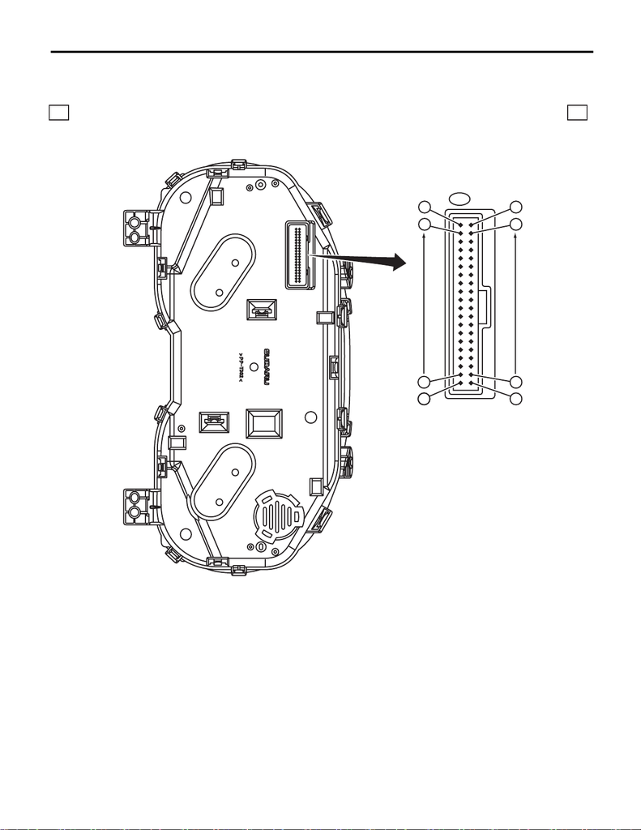

Combination Meter System

WIRING SYSTEM

13.Combination Meter System

A: WIRING DIAGRAM

WI-44329

i10

40

39

22

20

19

21

2

1

CONNECT

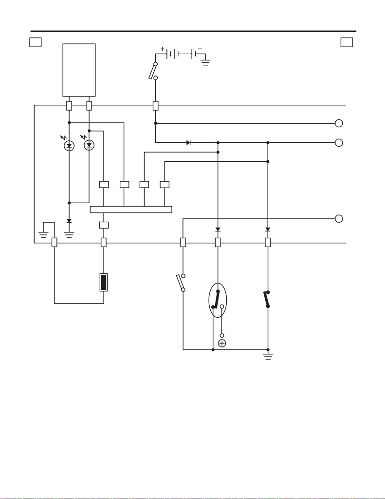

Combination Meter System

WIRING SYSTEM

WI-44330

b b

A

B

20

23

6

3

2

4

C

24

34

I/F

BATTERY

TURN SIGNAL &

HAZARD MODULE

IGNITION SWITCH (IG)

MICRO COMPUTER

SIDE TURN SIGNAL LH

SIDE TURN SIGNAL RH

OIL PRESSURE

SWITCH

GENERATOR

BRAKE FLUID LEVEL

SWITCH

REAR DIFFERENTIAL

OIL TEMPERATURE

SENSOR

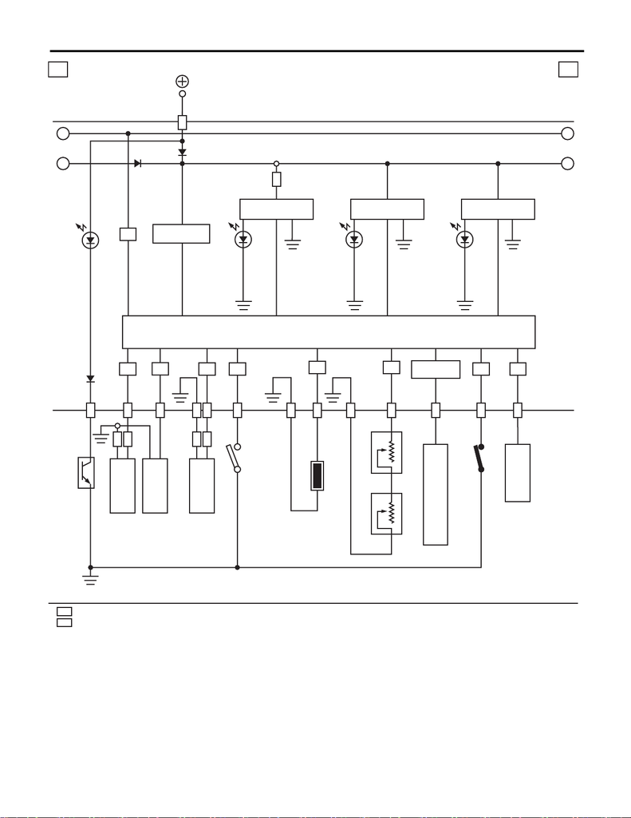

Combination Meter System

WIRING SYSTEM

WI-44331

c c

I/F I/F

D

E

FA

EJ

31

I/F

26

I/F

EJ

FA

FA

35

EJ

EJ

29

I/F

B

27

36

40

I/F

1

25

37

MFD

28

B

A

21

15

16

: ENGINE TYPE EJ

: ENGINE TYPE FA

MICRO COMPUTER

POWER SUPPLY

CIRCUIT

SECURITY/IMMOBILIZER

DRIVE CIRCUIT

(DIMMER)

DRIVE CIRCUIT

(DIMMER)

DRIVE CIRCUIT

(DIMMER)

PLATE

ILLUMI. LIGHT

INDICATOR NEEDLE

ILLUMI. LIGHT

STI LOGO

ILLUMI. LIGHT

DRIVE

CIRCUIT

AIRBAG CM

SEAT BELT SWITCH

(DRIVER'S SEAT)

FUEL LEVEL

SENSOR

FUEL SUB LEVEL

SENSOR

AMBIENT SENSOR

WASHER FLUID LEVEL SENSOR

SATELLITE

SWITCH

(SI-DRIVE)

MULTI SELECT

SWITCH

(SI-DRIVE)

STEERING

SWITCH

BODY

INTEGRATED UNIT

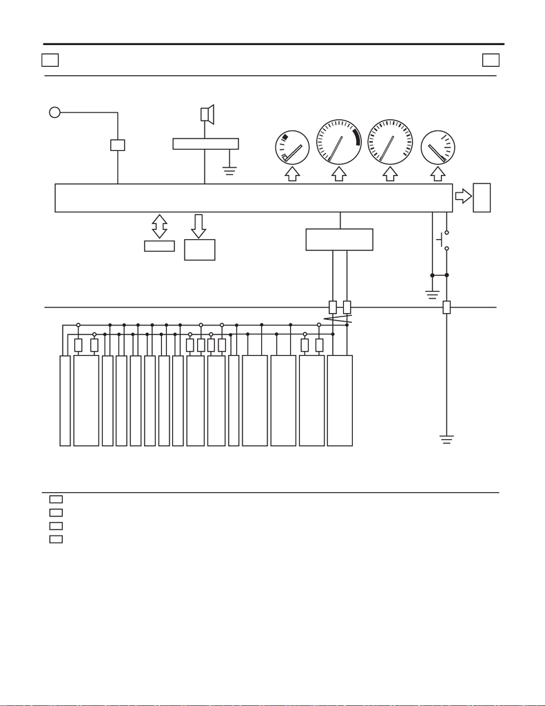

Combination Meter System

WIRING SYSTEM

WI-44332

d d

EJ

EJ

I/F

38

WE

WE

AL

AL

WP

WP

WP

C

WE

EJ

AL

TFT

EEPROM

MFD

33

32

ECM

VDC CM

TCM

E

F

C

H

: WITH PUSH BUTTON START

AUTO HEADLIGHT

BEAM LEVELER CM

KEYLESS ACCESS CM

BODY INTEGRATED UNIT

CAN TRANSCEIVER &

RECEIVER

REMOTE ENGINE START CM

DATA LINK CONNECTOR

IMPACT SENSOR

TRIP SWITCH

AIRBAG CM

STEERING ANGLE SENSOR

POWER STEERING CM

A/C CONTROL PANEL

SPEAKER

DRIVE CIRCUIT

DRIVE

CIRCUIT

MICRO COMPUTER

: WITH ELECTRIC POWER STEERING

: ENGINE TYPE EJ

: WITH AUTO HEADLIGHT BEAM LEVELER

DCCD CM

TACHOMETER SPEEDOMETER

ENGINE

COOLANT

TEMP.

GAUGE

FUEL GAUGE

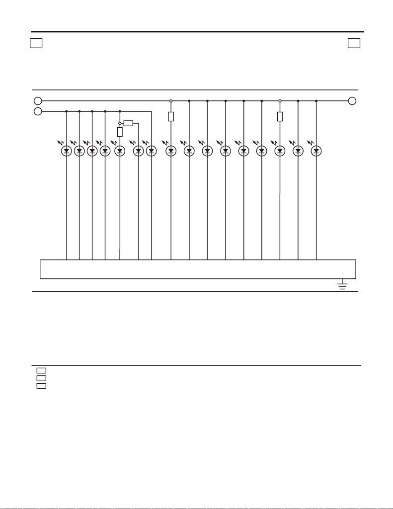

Combination Meter System

WIRING SYSTEM

e e

D F

E

WI-44333

FA

EJ

TI

EJ

TI

EJ

FA

DRIVE CIRCUIT

ABS

PARKING BRAKE/

BRAKE FLUID LEVEL

PARKING BRAKE/

BRAKE FLUID LEVEL/

BRAKE VACUUM PUMP

LED HEADLIGHT WARNING

TIRE INFLATION PRESSURE

CHARGE

DOOR

FUEL LEVEL

FRONT FOG LIGHT

LIGHTING

REV.

AUTO HEADLIGHT BEAM LEVELER

DRIVER'S SEAT BELT

STEERING

HILL START ASSIST

HI-BEAM

: ENGINE TYPE FA

: ENGINE TYPE EJ

: WITH TIRE INFLATION PRESSURE

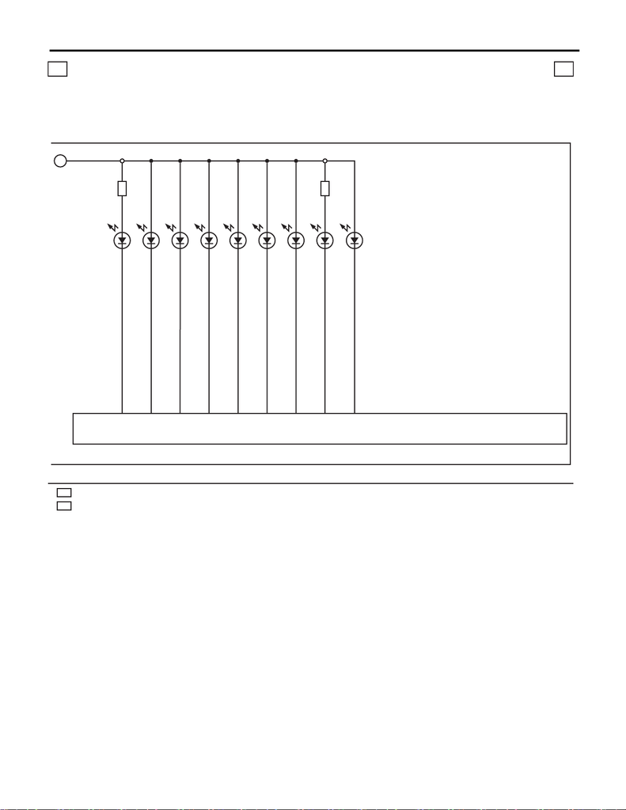

Combination Meter System

WIRING SYSTEM

WI-44334

f f

F

EF

EJ

EJ

EF

DRIVE CIRCUIT

: EXCEPT MT MODEL ENGINE TYPE FA

: ENGINE TYPE EJ

AWD

VDC OFF

VDC WARNING/VDC OPERATION

ATF TEMPERATURE

MALFUNCTION

AIRBAG

OIL PRESSURE

VDC TRACTION MODE

REAR DIFFERENTIAL OIL TEMPERATURE WARNING